# Getting Data from the Rapid Carbon Assessment Project

2013-08-14 Dylan Beaudette

## Introduction

This document demonstrates how to use the [soilDB](https://r-forge.r-project.org/scm/viewvc.php/*checkout*/docs/soilDB/soilDB-Intro.html?root=aqp) package to download [RaCA](http://soils.usda.gov/survey/raca/index.html) via SoilWeb. Comparisons are made via graphical summaries of key soil properties with depth, using [data structures and functions](https://r-forge.r-project.org/scm/viewvc.php/*checkout*/docs/aqp/aqp-intro.html?root=aqp) from the [aqp](http://aqp.r-forge.r-project.org/) package.

### The SoilWeb RaCA Query API

RaCA data are queried via HTTP request to the SoilWeb server, with query parameters encoded as [URL parameters](http://en.wikipedia.org/wiki/Query_string). For example, by appending several parameters to the base URL it is possible to query “site-level” data associated with soils correlated to the Auburn series like this:

```
http://casoilresource.lawr.ucdavis.edu/soil_web/rca/rca_query.php?what=site&series=auburn
```

There are 5 URL parameters that can be used to refine RaCA data queries:

- what=**site** ——*query only the site-level data*
- series=**auburn** ——*return only those data correlated to the Auburn series*
- bbox=**-120,37,-122,38** ——*return only those data within the specified bounding box, constrained to a 5-degree block*
- state=**ca** ——*return only those data within California*
- plaintext=**1** ——*return data as plain text instead of [gzipped](http://en.wikipedia.org/wiki/Gzip) text*

The **what** parameter determines which chunk of data will be returned:

- **site**: site and pedon level data
- **horizon**: horizon level data
- **veg**: vegetation information recorded at each site (relative abundence of 6 most common species)
- **trees**: tree height(feet) and [DBH](http://en.wikipedia.org/wiki/Diameter_at_breast_height)(inches) measured on the first for trees in using RaCA procdures
- **stock**: cumulative soil organic carbon stocks (Mg per ha) to standardized depths
- **sample**: measured/modeled bulk density and carbon concentration at the sample-level
- **vnir**: VNIR spectra [queries by soil series or BBOX only]

## Getting RaCA Data in R

The soilDB package abstracts URL-based queries for RaCA data into a single function, `fetchRaCA()`. Calling this function with user-defined query paramters, e.g. `fetchRaCA(series='auburn')`, will download all data (site, horizon, veg, trees, stock) associated with the Auburn series and return the results as a `list`. VNIR spectra can be very large and are therefore not downloaded by default.

### Installation

With a recent version of R (>= 2.15), it is possible to get all of the packages that this tutorial depends on via:

```r
# run these commands in the R console
install.packages('soilDB', dep=TRUE) # stable version from CRAN + dependencies
install.packages('soilDB', repos="http://R-Forge.R-project.org", type='source') # most recent copy from r-forge
```

### Example Usage

Data can be queried by two-letter state code, fuzzy-matching of series name, or using a geographic bounding-box in WGS84 referenced coordinates. See `?fetchRaCA()` for details.

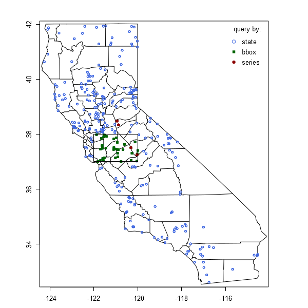

```r
# load libraries
library(soilDB)
library(plyr)
library(maps)
library(lattice)
library(reshape2)
library(cluster)

# define a geographic bounding box
bbox <- c(-120, 37, -122, 38)

# fetch data by soil series name
r.series <- fetchRaCA(series='auburn')

# fetch data by bounding box
r.bbox <- fetchRaCA(bbox=bbox)

# fetch data by state
r.state <- fetchRaCA(state='ca')

# map each set of fetched data
par(mar=c(0,0,0,0))
map('county', 'california')
points(y ~ x, data=site(r.state$pedons), col='RoyalBlue', cex=0.5, pch=1)
points(y ~ x, data=site(r.bbox$pedons), col='DarkGreen', cex=0.8, pch=15)
points(y ~ x, data=site(r.series$pedons), col='DarkRed', cex=0.8, pch=16)
# add bounding box
rect(bbox[1], bbox[2], bbox[3], bbox[4])
# add long/lat axes
map.axes()
# add a simple legend
legend('topright', pch=c(1, 15, 16), col=c('RoyalBlue', 'DarkGreen', 'DarkRed'), legend=c('state', 'bbox', 'series'), bty='n', title='query by:')
```

### Exploring the Results

A list of objects and tables (`data.frame` objects) is returned by `fetchRaCA()`. Elements can be accessed using the `$` operator.

```r
# check structure
str(r.bbox, 2)
```

```
## List of 6
##  $ pedons :Formal class 'SoilProfileCollection' [package "aqp"] with 7 slots
##  $ trees  :'data.frame': 28 obs. of  3 variables:
##   ..$ siteiid: int [1:28] 605539 605539 605539 605539 605563 605563 605563 605563 605642 605642 ...
##   ..$ dbh    : num [1:28] 11.5 25 48 50 8 ...
##   ..$ height : num [1:28] 36 39 45 54 30 ...
##  $ veg    :'data.frame': 88 obs. of  6 variables:
##   ..$ siteiid              : int [1:88] 605539 605539 605539 605539 605539 605539 605551 605551 605551 605551 ...
##   ..$ plantsym             : chr [1:88] "AVFA" "ERODI" "LUPIN" "MONTI" ...
##   ..$ plantsciname         : chr [1:88] "Avena fatua" "Erodium" "Lupinus" "Montia" ...
##   ..$ plantnatvernm        : chr [1:88] "wild oat" "storks bill" "lupine" "minerslettuce" ...
##   ..$ vegetationstratalevel: logi [1:88] NA NA NA NA NA NA ...
##   ..$ orderofdominance     : logi [1:88] NA NA NA NA NA NA ...
##  $ stock  :'data.frame': 204 obs. of  13 variables:
##   ..$ rcapid     : chr [1:204] "A0208P941" "A0208P942" "A0208P943" "A0208P944" ...
##   ..$ value_5cm  : num [1:204] 17.8 18.4 14.9 22.8 23.2 ...
##   ..$ sd_5cm     : num [1:204] 11.2 12.2 10.1 14.6 15 ...
##   ..$ value_10cm : num [1:204] 41.5 32.9 40 45.1 40.6 ...
##   ..$ sd_10cm    : num [1:204] 17.7 14.6 18 20.3 19.8 ...
##   ..$ value_20cm : num [1:204] 90.4 58.7 79.2 89.1 77.6 ...
##   ..$ sd_20cm    : num [1:204] 44.6 28.2 39.4 41.2 38.4 ...
##   ..$ value_30cm : num [1:204] 125 85.1 112.2 127.5 114.2 ...
##   ..$ sd_30cm    : num [1:204] 52.4 32.5 44.3 48.9 51.1 ...
##   ..$ value_50cm : num [1:204] 198 139 173 206 196 ...
##   ..$ sd_50cm    : num [1:204] 77.9 55.6 75.6 85 87.1 ...
##   ..$ value_100cm: num [1:204] 248 198 246 255 302 ...
##   ..$ sd_100cm   : num [1:204] 90.9 75.7 91.1 91.4 107.7 ...
##  $ sample :'data.frame': 938 obs. of  16 variables:
##   ..$ sample_id    : int [1:938] 12935 12934 12933 12932 12936 12941 12937 12938 12939 12940 ...
##   ..$ rcapid       : chr [1:938] "A0208P941" "A0208P941" "A0208P941" "A0208P941" ...
##   ..$ sample_top   : int [1:938] 54 19 5 0 69 72 0 5 21 55 ...
##   ..$ sample_bottom: int [1:938] 69 54 19 5 69 72 5 21 55 72 ...
##   ..$ hzname       : chr [1:938] "Bt" "BAt" "A2" "A1" ...
##   ..$ texture      : chr [1:938] "sc" "sl" "sl" "sl" ...
##   ..$ frag_vol     : int [1:938] 0 0 0 0 0 0 0 0 0 0 ...
##   ..$ bd           : num [1:938] 1.37 1.6 1.71 1.29 1.29 ...
##   ..$ bd_sd        : num [1:938] 0.2085 0.0652 0.0652 0.0652 0.2085 ...
##   ..$ bd_source    : chr [1:938] "modeled" "measured" "measured" "measured" ...
##   ..$ bd_method    : chr [1:938] "" "core, constant volume" "core, constant volume" "scoop" ...
##   ..$ soc          : num [1:938] 2.02 2.22 2.87 2.82 1.19 ...
##   ..$ soc_sd       : num [1:938] 1.25 1.38 1.78 1.75 2.17 ...
##   ..$ soc_measured : chr [1:938] "modeled" "modeled" "modeled" "modeled" ...
##   ..$ soc_scan     : logi [1:938] NA NA NA NA NA NA ...
##   ..$ soc_lab      : num [1:938] NA NA NA NA NA NA NA NA NA NA ...
##  $ spectra: NULL
```

### Site/Pedon Data

Site and pedon data are returned as a [SoilProfileCollection object](https://r-forge.r-project.org/scm/viewvc.php/*checkout*/docs/aqp/aqp-intro.html?root=aqp) within the `pedons` list element.

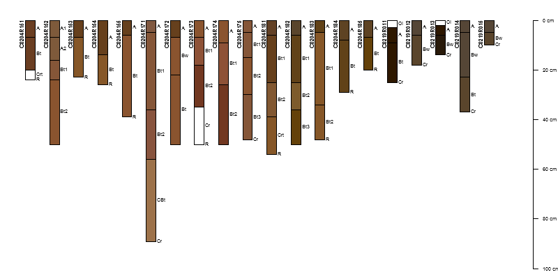

```r
# extract site/pedon data
s <- r.series$pedons

# how many pedons in the collection?
length(s)

# how many pedons / RCA site?
table(s$rcasiteid)

# generate soil colors from moist RGB
s$soil_color <- rep(NA, times=nrow(horizons(s)))
idx <- complete.cases(s$m_r)
s$soil_color[idx] <- with(horizons(s)[idx, ], rgb(m_r, m_g, m_b)) # moist colors

# plot first 20 pedons
par(mar=c(0,0,0,0))
plot(s[1:20, ], name='hzname', max.depth=100)
```

### Vegetation Data

```r
# tabulate vegetation data across the entire collection of RaCA data queried by BBOX
sort(table(r.bbox$veg$plantnatvernm), decreasing=TRUE)
```

```
##
##                 wild oat              storks bill                 blue oak               soft brome
##                        7                        6                        5                        5
## California foothill pine        interior live oak       Pacific poison oak             ripgut brome
##                        3                        3                        3                        3
##                    brome     California black oak                   fescue                   lupine
##                        2                        2                        2                        2
##            minerslettuce             mouse barley              slender oat                  thistle
##                        2                        2                        2                        2
##               wheatgrass             Bermudagrass            bigleaf maple            black mustard
##                        2                        1                        1                        1
##                bluegrass   bristly dogstail grass                 brodiaea             bull thistle
##                        1                        1                        1                        1
##       California juniper        California laurel      California live oak                   clover
##                        1                        1                        1                        1
##   coastal sage scrub oak        coastal sagebrush                     corn               curly dock
##                        1                        1                        1                        1
##                     dock            Grass; annual            incense cedar         Italian ryegrass
##                        1                        1                        1                        1
##                 knotweed                 live oak               medusahead             monkeyflower
##                        1                        1                        1                        1
##                  mullein                      oat           ponderosa pine                  redwood
##                        1                        1                        1                        1
##                    sedge               sugar pine                   tanoak                  tarweed
##                        1                        1                        1                        1
##                    vetch                   walnut      western brackenfern               woodsorrel
##                        1                        1                        1                        1
```

```r
# aggregate tree information, by RaCA site
ddply(r.bbox$trees, 'siteiid', summarize, mean.dbh=mean(dbh), mean.height=mean(height), n=length(siteiid))
```

```
##   siteiid mean.dbh mean.height n
## 1  605539    33.62       43.50 4
## 2  605563    14.50       36.75 4
## 3  605642    11.57       17.47 4
## 4  605645    26.20       72.35 4
## 5  682304    20.25       68.25 4
## 6  682305    21.75       34.50 4
## 7  682445    21.88       42.88 4
```

### Soil Organic Carbon Concentrations

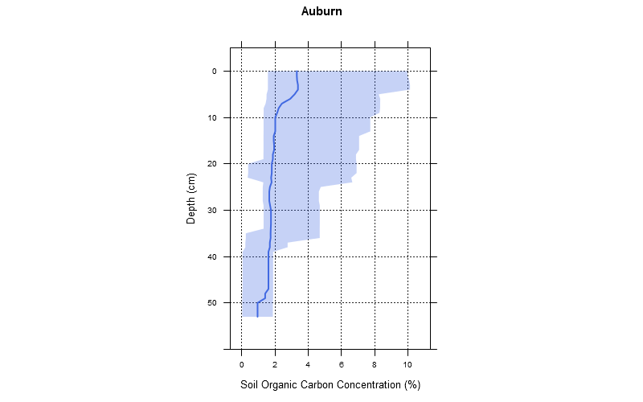

```r
# extract sample data horizon-level carbon and bulk density
s <- r.series$sample

# init SoilProfileCollection
depths(s) <- rcapid ~ sample_top + sample_bottom

# slice-wise aggregation over entire collection
a <- slab(s, ~ soc)

# plot
xyplot(
  top ~ p.q50, data=a, main='Auburn', ylab='Depth (cm)', xlab='Soil Organic Carbon Concentration (%)',
  lower=a$p.q5, upper=a$p.q95, sync.colors=TRUE, alpha=0.3,
  ylim=c(60,-5), asp=1.5,
  par.settings=list(superpose.line=list(lwd=2, col=c('RoyalBlue'))),
  panel=panel.depth_function,
  prepanel=prepanel.depth_function,
  auto.key=list(columns=2, lines=TRUE, points=FALSE)
)
```

### Soil Organic Carbon Stock Data

```r
# join carbon stock estimates to SPC object
# these are site-level data
s <- r.bbox$pedons
site(s) <- r.bbox$stock

# compute mean SOC stock to 100cm by RCA site:
round(tapply(s$value_100cm, s$rcasiteid, mean))
```

```
## A0208P94 A0215P99 C0204C01 C0204F12 C0204R04 C0204R13 C0204R18 C0205C05 C0205C06 C0205C07 C0205R01
##      250      161      248      157      173      177       90      513      153      217      270
## C0206C05 C0206W02 C0206W04 C0208C02 C0208C05 C0208F11 C0208P02 C0208R10 C0209C01 C0209C04 C0209F04
##      404      272      152      270      320      411      281      131      179      494      338
## C0209F09 C0209F17 C0209F24 C0209R16 C0209R23 C0212C02 C0212C05 C0212C06 C0212C08 C0213C06 C0213C14
##      168      275      511      327      169      266      923      260      315      277      199
## C0215C07 C0215F06 C0218P02 C0218P05 C0219C05 C0219F04 C0219P04 C0219R01
##      290      260      460      307      225      253      339      168
```

```r
# compute mean SOC stock to 100cm by series:
round(tapply(s$value_100cm, s$taxonname, mean))
```

```
##         Altamont           Auburn       Ben Lomond          Briones         Campbell
##              169              129              399              270              404
##           Cometa          Cropley            Delhi           Felton           Fresno
##              250              320              294              640              225
##          Gonzaga          Hanford            Itano Josephine family          Katykat
##              260              339              199              253              411
##          Kingile          Lompico        Los Gatos           Maymen       Poterville
##              260              439              253              157              161
##           Rindge      San Andreas      San Joaquin          Shinkee       Stanislaus
##              923              301              266              266              290
##           Temple         Triangle          Tujunga           Valdez       Vallecitos
##              384              212              494              277              161
##           Webile        Zacharias
##              315              179
```

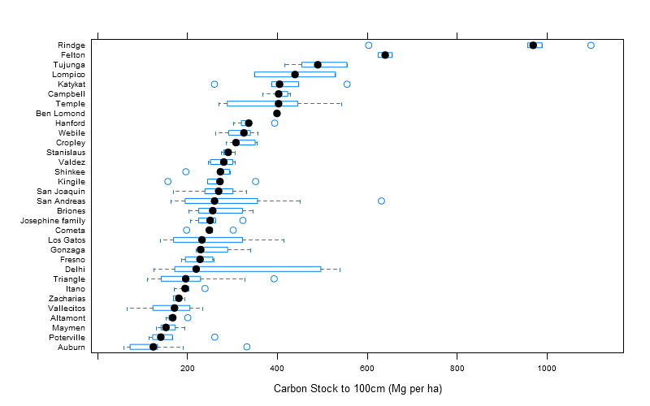

```r
# convert taxonname to a factor
s$taxonname <- factor(s$taxonname)

# re-level based on median C stock
stock.asc.order <- order(tapply(s$value_100cm, s$taxonname, median))
new.levels <- levels(s$taxonname)[stock.asc.order]
s$taxonname <- factor(s$taxonname, levels=new.levels)

# visualize
bwplot(taxonname ~ value_100cm, data=site(s), xlab='Carbon Stock to 100cm (Mg per ha)')
```

### Depth-Wise Aggregation of Carbon Stock Data

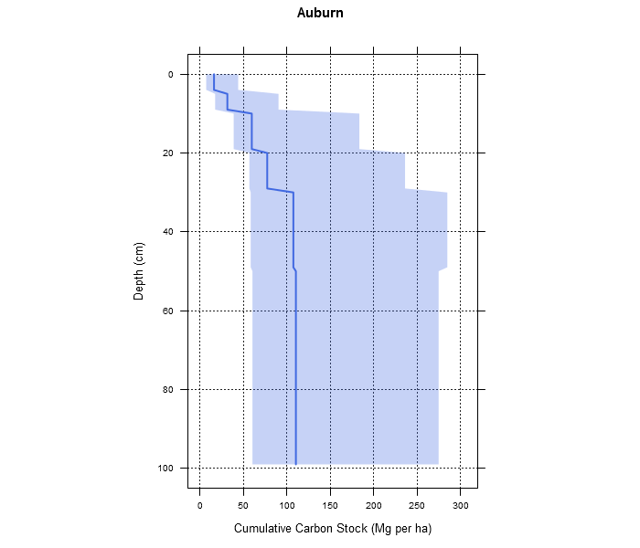

```r
m <- melt(r.series$stock, id.vars='rcapid', measure.vars=c(2,4,6,8,10,12))

# fix c stock variable name
names(m)[3] <- 'c.stock'

# generate depths from variable names
m$top <- NA
m$bottom <- NA

# sequence of possible top/bottom boundaries
m.top <- c(0,5,10,20,30,50)
m.bottom <- c(5,10,20,30,50,100)

# generate an index to real depths
# this only works because the factor levels are in the correct order
mm <- as.numeric(m$variable)

# assign real depths
m$top <- m.top[mm]
m$bottom <- m.bottom[mm]

# promote to SPC
depths(m) <- rcapid ~ top + bottom

# simple aggregation of the entire collection: note that this doesn't take into account error estimates...
a <- slab(m, ~ c.stock)

# plot aggregate data
xyplot(
  top ~ p.q50, data=a, main='Auburn', ylab='Depth (cm)', xlab='Cumulative Carbon Stock (Mg per ha)',
  lower=a$p.q5, upper=a$p.q95, sync.colors=TRUE, alpha=0.3,
  ylim=c(105,-5), asp=1.5,
  par.settings=list(superpose.line=list(lwd=2, col=c('RoyalBlue'))),
  panel=panel.depth_function,
  prepanel=prepanel.depth_function,
  auto.key=list(columns=2, lines=TRUE, points=FALSE)
)
```

### VNIR Spectra

VNIR spectra are large, and therefore not downloaded by default. The `get.vnir=TRUE` argument to `fetchRaCA()` will download VNIR spectra associated with the query results.

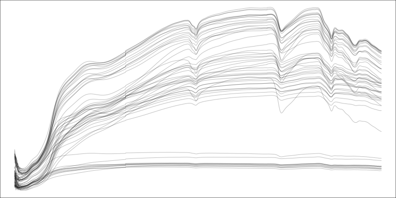

```r
s <- fetchRaCA(series='auburn', get.vnir=TRUE)

# plot the spectra
par(mar=c(0,0,0,0))
matplot(t(s$spectra), type='l', lty=1, col=rgb(0, 0, 0, alpha=0.25), ylab='', xlab='', axes=FALSE)
box()
```

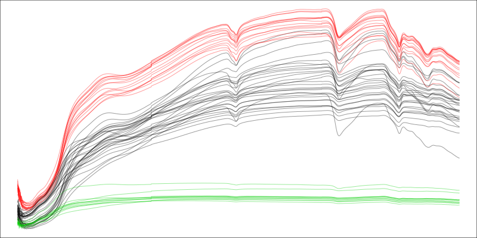

```r
# Q-mode PCA of spectra
pca <- prcomp(s$spectra, center=TRUE, scale=TRUE)
summary(pca)

# cluster on first 3 principal components into 3 hard groupings via PAM
spectra.pam <- pam(predict(pca)[, 1:3], 3)

# re-plot spectra, colored by 3-class clustering
cols <- rgb(t(col2rgb(spectra.pam$clustering)), maxColorValue=255, alpha=100)
matplot(t(s$spectra), type='l', lty=1, col=cols, ylab='', xlab='', axes=FALSE)
box()
```

This document is based on `aqp` version 1.5-4 and `soilDB` version 1.2.